B10703049 財金二 柯宥圻 作業一

我使用Google colab完成此作業

I use google colab to do this homework.

# Question 1

## what we are going to do :

build a matrix A and vector b such that Ax = b, where the data is given in the assignment page. We use numpy to build the matrix and vector, and we will try to solve the following problems. The first problem is just building this linear system.

```python
# Question 1-(a)
import numpy as np
A = np.array([[2,1,0,-4],[1,0,0.25,-1],[-2,-1.1,0.25,6.2],[4,2.2,0.3,-2.4]])
b = np.array([-3,-1.5,5.6,2.2])
print("Matrix A:")
print(A)
print("Vector b:")
print(b)
```

```
Matrix A:
[[ 2.    1.    0.   -4.  ]
 [ 1.    0.    0.25 -1.  ]
 [-2.   -1.1   0.25  6.2 ]
 [ 4.    2.2   0.3  -2.4 ]]
Vector b:
[-3.  -1.5  5.6  2.2]
```

We can see the matrix and vector above.

Then, in problem 1-b, we want to solve the system with numpy.linalg.

```python
# Question 1-(b)
x = np.linalg.solve(A, b)
x
```

```
array([ 0.5,  2. , -2. ,  1.5])
```

We can see the answer above. x1=0.5, x2=2, x3=-2, x4=1.5.

Then, in problem 1-c, we want to find the inverse of matrix A, i.e., A^(-1), with numpy.linalg. We will calculate A^(-1)b, too.

```python
# Question 1-(c)
A_inv = np.linalg.inv(A)
print("Inverse of matrix A:")
print(A_inv)

x = np.dot(A_inv, b)
print("Solution:")
print(x)
```

```
Inverse of matrix A:
[[-9.075  2.65  -4.75   1.75 ]
 [10.35  -3.7    5.5   -1.5  ]
 [27.5   -5.    15.    -5.   ]
 [-2.2    0.4   -1.     0.5  ]]
Solution:
[ 0.5  2.  -2.   1.5]
```

the matrix A^(-1) is shown above.

We can see the answer above. x1=0.5, x2=2, x3=-2, x4=1.5, which is the same as the Ax=b. We can see the answer of A^(-1)x=b is identical as Ax=b.

When we solve the linear system Ax = b using the numpy.linalg.solve function, we are directly finding the values of x that satisfy the equation Ax = b. On the other hand, when we find A^(-1)*b, we are first finding the inverse of the matrix A and then multiplying it with the vector b to obtain the solution vector x. However, mathematically, we know that if we multiply both sides of the equation Ax = b by A^(-1), we get:

A^(-1)Ax = A^(-1)*b

Simplifying the left-hand side, we get:

Ix = A^(-1)*b

where I is the identity matrix. Therefore, we get:

x = A^(-1)*b

This shows that the solution obtained by finding A^(-1)*b is the same as the solution obtained by solving the linear system Ax = b

Finally, we want to find the LU-factorization of the coefficient matrix of system Ax=b:

```python
# Question 1-(d)

import scipy
p, l, u = scipy.linalg.lu(A)
# Print the factors
print("Permutation matrix P:")
print(p)
print("Lower-triangular matrix L:")
print(l)
print("Upper-triangular matrix U:")
print(u)
```

```
Permutation matrix P:
[[0. 0. 0. 1.]
 [0. 1. 0. 0.]
 [0. 0. 1. 0.]
 [1. 0. 0. 0.]]
Lower-triangular matrix L:
[[ 1.          0.          0.          0.        ]
 [ 0.25        1.          0.          0.        ]
 [-0.5        -0.          1.          0.        ]
 [ 0.5         0.18181818 -0.45454545  1.        ]]
Upper-triangular matrix U:
[[ 4.          2.2         0.3        -2.4       ]
 [ 0.         -0.55        0.175      -0.4       ]
 [ 0.          0.          0.4         5.        ]
 [ 0.          0.          0.         -0.45454545]]
```

We can see the Permutation matrix P, Lower-triangular matrix L, and Upper-triangular matrix U. To check whether A = PLU, we try to dot them together.

```python
print("Product of PLU:")
print(np.dot(p, np.dot(l, u)))
```

```
Product of PLU:
[[ 2.00000000e+00  1.00000000e+00 -2.11951668e-17 -4.00000000e+00]
 [ 1.00000000e+00  0.00000000e+00  2.50000000e-01 -1.00000000e+00]
 [-2.00000000e+00 -1.10000000e+00  2.50000000e-01  6.20000000e+00]
 [ 4.00000000e+00  2.20000000e+00  3.00000000e-01 -2.40000000e+00]]
```

We can see that the answer is composed correctly.

# Question 2

## what we are going to do:

we want to do some image processing and filters. First, we try to use matrix addition to decorate TA's picture.

```python
from google.colab import drive
drive.mount('/content/drive')
```

```python
# Question 2-(a)

import cv2
TA = cv2.imread('/content/drive/MyDrive/TAphoto.jpg')
nums = cv2.imread('/content/drive/MyDrive/nums.jpg')
nums_resized = cv2.resize(nums, (TA.shape[1], TA.shape[0]))
img = cv2.add(TA,nums_resized)
from google.colab.patches import cv2_imshow
cv2_imshow(img)
```

```
Output hidden; open in https://colab.research.google.com to view.
```

The next question has the same notion as question a.

```python
# Question 2-(b)
img = cv2.subtract(TA,nums_resized)
cv2_imshow(img)
```

```
Output hidden; open in https://colab.research.google.com to view.
```

we just alter from add to subtract, and the answer show. The next question is that we need to rotate and scale the TA's picture using Opencv. Therefore, we use the cv2 function package to show if it works

```python
# Question 2-(c)
(h, w, d) = TA.shape
center = (w // 2, h // 2)
M = cv2.getRotationMatrix2D(center, -120, 0.5)
rotate_img = cv2.warpAffine(TA, M, (w, h))

cv2_imshow(rotate_img)
```

```
Output hidden; open in https://colab.research.google.com to view.
```

First, since we need to find the center of the picture to rotate it, we have to detect the size of this picture forst. Therefore, we use TA.shape() to find the dimensions data, and find the center of it. Then, we use the getRotationMatrix2D function to rotate and rescale it. In that function, the first parameter is to define the rotation center, the second one is to determine the degree the picture should turn. (counterclockwise: +. clockwise: -). The third parameter is to define the scaling ratio.

Last but not least, we use warpAffine to display the picture and show that The size of the picture after the third parameter is changed

The question 2-d is to use canny edge detection to detect the contour of TA's picture.

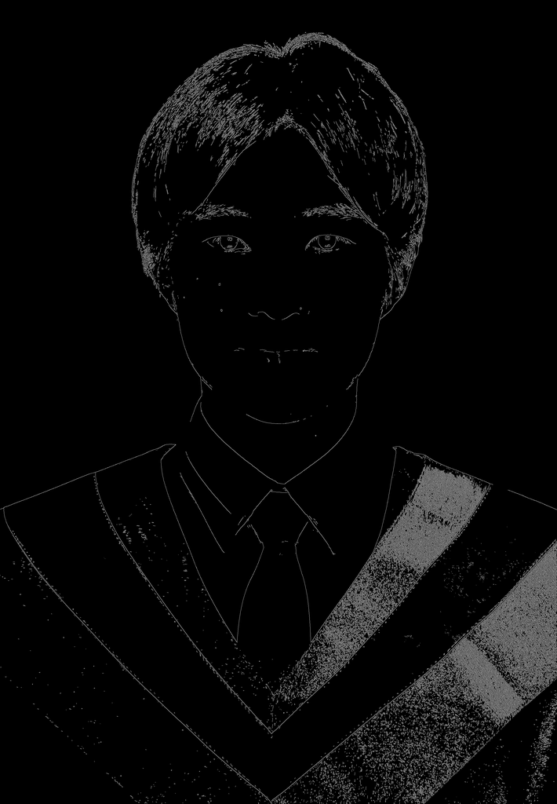

```python
canny = cv2.Canny(TA, 100, 150)
cv2_imshow(canny)
cv2.waitKey(0)
cv2.destroyAllWindows()
```

We simply use cv2.Canny to show the edge of his picture. It is quite simple to use Canny. we just need to pass in the image parameters and specify two threshold parameters threshold1 and threshold2, which means that if the value of any point pixel in the graphic is greater than threshold2, it is considered to be an edge pixel, and if it is less than threshold1, it is not an edge pixel. The pixeles between the two is determined by the program after calculating according to the pixel intensity value.

```python
%%shell
jupyter nbconvert --to html /content/drive/MyDrive/MM01_B10703049_柯宥圻.ipynb
```

```
[NbConvertApp] Converting notebook /content/drive/MyDrive/MM01_B10703049_柯宥圻.ipynb to html
[NbConvertApp] Writing 946494 bytes to /content/drive/MyDrive/MM01_B10703049_柯宥圻.html
```